# Travel Package Purchase Prediction

## ProdTaken Vs Categorical Variables

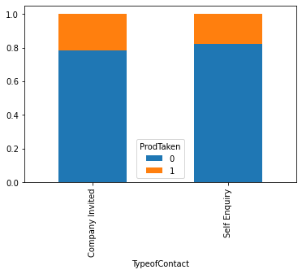

```python
tpc=pd.crosstab(df['TypeofContact'],df['ProdTaken'])
tpc.div(tpc.sum(1).astype(float), axis=0).plot(kind='bar',stacked=True)
```

This shows that the customers who took the travel package was those who came into company's contact as company invited

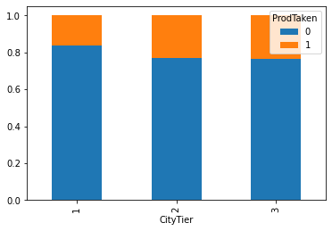

```python
ct=pd.crosstab(df['CityTier'],df['ProdTaken'])
ct.div(ct.sum(1).astype(float), axis=0).plot(kind='bar',stacked=True)
```

The customers from city tier 2 and 3 have are most likely or mostly purchased the travel package

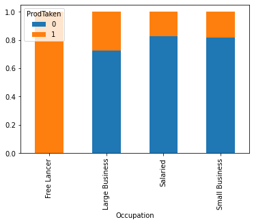

```python
occ=pd.crosstab(df['Occupation'],df['ProdTaken'])
occ.div(occ.sum(1).astype(float), axis=0).plot(kind='bar',stacked=True)
```

This shows that all the customers who are "Free Lancers" have purchased the product and also customers that own or work for "Large Business" have also purchased the product.

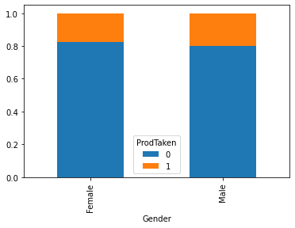

```python
gender=pd.crosstab(df['Gender'],df['ProdTaken'])
gender.div(gender.sum(1).astype(float), axis=0).plot(kind='bar',stacked=True)
```

From the graph it reveals that there is not really much difference between the genders of the customers who have purchased the travel package

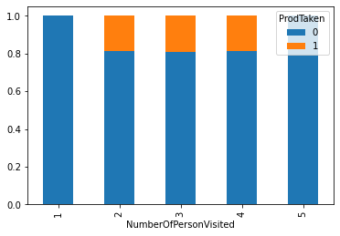

```python
npv=pd.crosstab(df['NumberOfPersonVisited'],df['ProdTaken'])
npv.div(npv.sum(1).astype(float), axis=0).plot(kind='bar',stacked=True)
```

- Customers are tracelling with 2,3,4 persons have a higher chance of obtaining the travel package
- Whereas customers travelling with either 1 or 5 persons are less likely or did not acquire any travel package

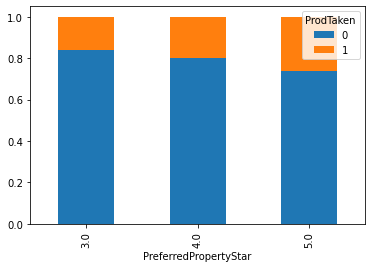

```python
ppp=pd.crosstab(df['PreferredPropertyStar'],df['ProdTaken'])
ppp.div(ppp.sum(1).astype(float), axis=0).plot(kind='bar',stacked=True)
```

Customers who prefer 5 star rated property has brought the travel package more followed by 4 and 3 star preferred customers

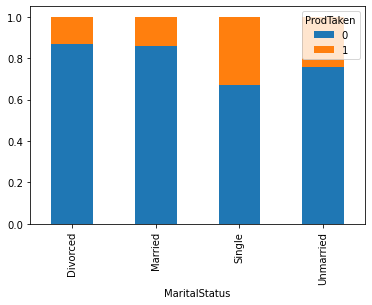

```python
ms=pd.crosstab(df['MaritalStatus'],df['ProdTaken'])
ms.div(ms.sum(1).astype(float), axis=0).plot(kind='bar',stacked=True)
```

Customers who are single and unmarried people have purchased the travel package in comparison to the married or divorced customers

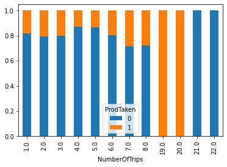

```python
ntrips=pd.crosstab(df['NumberOfTrips'],df['ProdTaken'])
ntrips.div(ntrips.sum(1).astype(float), axis=0).plot(kind='bar',stacked=True)
```

Customers that take 7 or 8 trips per year has more chace of pacquiring the travel package.Also those those travel 2 or times per year has about 20% chance of purchasing the package

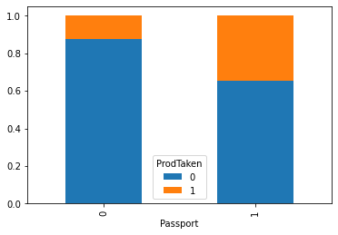

```python
passp=pd.crosstab(df['Passport'],df['ProdTaken'])
passp.div(passp.sum(1).astype(float), axis=0).plot(kind='bar',stacked=True)
```

Customers who own passport are more likely to purchase the travel package compared to customers that do not own passport

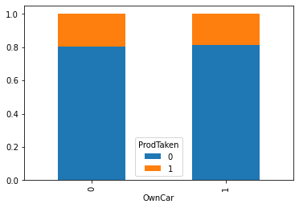

```python
car=pd.crosstab(df['OwnCar'],df['ProdTaken'])
car.div(car.sum(1).astype(float), axis=0).plot(kind='bar',stacked=True)
```

There is not much difference in purchasing travel package between customers with and without a car

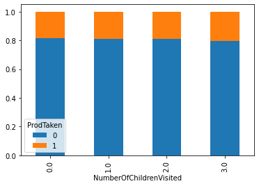

```python
ncv=pd.crosstab(df['NumberOfChildrenVisited'],df['ProdTaken'])
ncv.div(ncv.sum(1).astype(float), axis=0).plot(kind='bar',stacked=True)
```

There is no significant difference in the purchasing travel package for customers who had 0,1,2,3 children visiting with them.

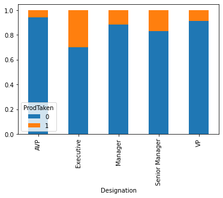

```python
desi=pd.crosstab(df['Designation'],df['ProdTaken'])
desi.div(desi.sum(1).astype(float), axis=0).plot(kind='bar',stacked=True)
```

This shows that customers in "Executive" position are more likely or have purchased the travel package, followed by customers in the "senior manager" position.

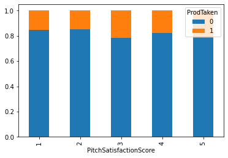

```python
pss=pd.crosstab(df['PitchSatisfactionScore'],df['ProdTaken'])
pss.div(pss.sum(1).astype(float), axis=0).plot(kind='bar',stacked=True)
```

Those customers who have given a PitchSatisfactionScore of 3 or 5 have purchased the travel package more

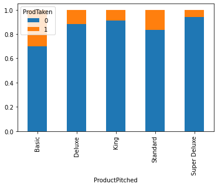

```python
pp=pd.crosstab(df['ProductPitched'],df['ProdTaken'])
pp.div(pp.sum(1).astype(float), axis=0).plot(kind='bar',stacked=True)
```

The package was purchased by those customers to whom the Basic product was pitched, followed by standard product

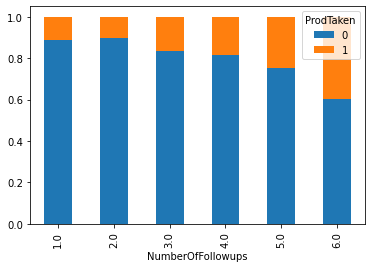

```python
nf=pd.crosstab(df['NumberOfFollowups'],df['ProdTaken'])
nf.div(nf.sum(1).astype(float), axis=0).plot(kind='bar',stacked=True)
```

The chance of purchasing increased as the number of followups went up with number of followups of 6 showing good chance of the customer purchasing the package.

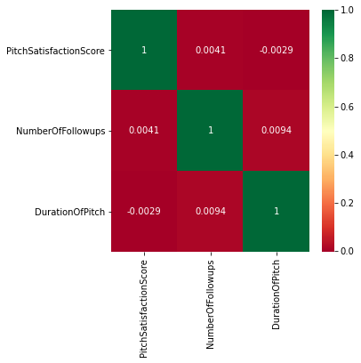

```python
corrmat = df[['PitchSatisfactionScore', 'NumberOfFollowups', 'DurationOfPitch']].corr()
top_corr_features = corrmat.index
plt.figure(figsize=(5,5))
#plot heat map
g=sns.heatmap(df[top_corr_features].corr(),annot=True,cmap="RdYlGn")
```

This graph shows that there is no much interaction between 'PitchSatisfactionScore', 'NumberOfFollowups' and 'DurationOfPitch' variables.

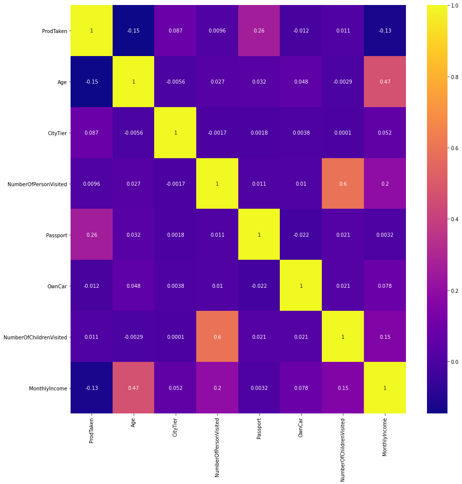

```python
corrmat = df[['ProdTaken', 'Age', 'TypeofContact', 'CityTier', 'Occupation', 'Gender', 'NumberOfPersonVisited', 'PreferredPropertyStar', 'MaritalStatus', 'NumberOfTrips', 'Passport',
   'OwnCar', 'NumberOfChildrenVisited', 'Designation', 'MonthlyIncome']].corr()
top_corr_features = corrmat.index
plt.figure(figsize=(15,15))
#plot heat map
g=sns.heatmap(df[top_corr_features].corr(),annot=True,cmap="plasma")
```

#### Observations

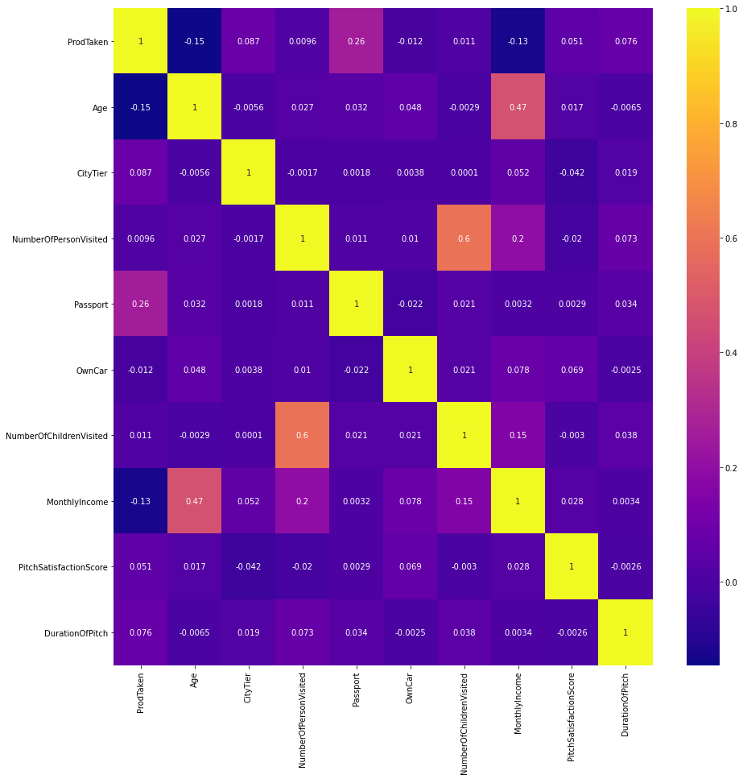

```python
corrmat2 = df[['ProdTaken', 'Age', 'TypeofContact', 'CityTier', 'Occupation', 'Gender', 'NumberOfPersonVisited', 'PreferredPropertyStar', 'MaritalStatus', 'NumberOfTrips', 'Passport',
   'OwnCar', 'NumberOfChildrenVisited', 'Designation', 'MonthlyIncome', 'PitchSatisfactionScore', 'NumberOfFollowups', 'DurationOfPitch']].corr()
top_corr_features2 = corrmat2.index
plt.figure(figsize=(15,15))
#plot heat map
g=sns.heatmap(df[top_corr_features2].corr(),annot=True,cmap="plasma")
```

## General Observation from EDA

- Customers who purchased travel package preferred 5 star rated properties and were mostly from city tier 2,3 which they were mostly who came into the company's contact as company invite
- Single and unmarried customers has higher chance of purchasing the travel package.Also customers having 2,3,4 persons travelling with them has more chance of buying the travel package
- The holiday package has been taken mostly by customers who are above 30 years of age and who are in executive positions
- Customer who travel 7 or 8 trips per year have a higher chance of purchasing the travel package
- Also having a passport showed chances of purchasing the package
- For occupation the FreeLancers and Large Business owners have higher chance of purchasing the travel package
- Variables that did not have much impact travel package were Gender,number of children visiting and having a car.

#### While in terms of customer interaction data customers mostly purchased the travel package when

- The PitchSatisfactionScore was either 3 or 5
- The product pitched was Basic or standard product
- The longer duration of pitch by salesman to the customer
- The number of followups was high as with the number of 6 followups which displayed the higher chance of a customer acquiring the travel package

# Missing Values Detection and Outlier Treatment

## 1. Missing value tratment

## 2. Outlier Detection

## 3. Feature Engineering

### Checking missing values in Dataset

```python
df.isnull().sum()
```

```
CustomerID                   0
ProdTaken                    0
Age                        226
TypeofContact               25
CityTier                     0
DurationOfPitch            251
Occupation                   0
Gender                       0
NumberOfPersonVisited        0
NumberOfFollowups           45
ProductPitched               0
PreferredPropertyStar       26
MaritalStatus                0
NumberOfTrips              140
Passport                     0
PitchSatisfactionScore       0
OwnCar                       0
NumberOfChildrenVisited     66
Designation                  0
MonthlyIncome              233
dtype: int64
```

From above we can see clearly in columns Age, TypeOfContact,DurationOfPitch, NumberOfFollowups, PreferredPropertyStar, NumberOfTrips, NumberOfChildrenVisited and MonthlyIncome all have missing values in them

### Missing Value Treatment

```python
#checking for thw rows where Age is missing
df[df["Age"].isnull()]
```

|  | CustomerID | ProdTaken | Age | TypeofContact | CityTier | DurationOfPitch | Occupation | Gender | NumberOfPersonVisited | NumberOfFollowups | ProductPitched | PreferredPropertyStar | MaritalStatus | NumberOfTrips | Passport | PitchSatisfactionScore | OwnCar | NumberOfChildrenVisited | Designation | MonthlyIncome |
| --- | --- | --- | --- | --- | --- | --- | --- | --- | --- | --- | --- | --- | --- | --- | --- | --- | --- | --- | --- | --- |
| 4 | 200004 | 0 | NaN | Self Enquiry | 1 | 8.0 | Small Business | Male | 2 | 3.0 | Basic | 4.0 | Divorced | 1.0 | 0 | 5 | 1 | 0.0 | Executive | 18468.0 |
| 11 | 200011 | 0 | NaN | Self Enquiry | 1 | 21.0 | Salaried | Female | 2 | 4.0 | Deluxe | 3.0 | Single | 1.0 | 1 | 3 | 0 | 0.0 | Manager | NaN |
| 19 | 200019 | 0 | NaN | Self Enquiry | 1 | 8.0 | Salaried | Male | 2 | 3.0 | Basic | 3.0 | Single | 6.0 | 1 | 4 | 0 | 1.0 | Executive | NaN |
| 20 | 200020 | 0 | NaN | Company Invited | 1 | 17.0 | Salaried | Female | 3 | 2.0 | Deluxe | 3.0 | Married | 1.0 | 0 | 3 | 1 | 2.0 | Manager | NaN |
| 21 | 200021 | 1 | NaN | Self Enquiry | 3 | 15.0 | Salaried | Male | 2 | 4.0 | Deluxe | 5.0 | Single | 1.0 | 0 | 2 | 0 | 0.0 | Manager | 18407.0 |
| ... | ... | ... | ... | ... | ... | ... | ... | ... | ... | ... | ... | ... | ... | ... | ... | ... | ... | ... | ... | ... |
| 2410 | 202410 | 1 | NaN | Self Enquiry | 1 | 30.0 | Small Business | Male | 2 | 3.0 | Basic | 4.0 | Married | 2.0 | 1 | 1 | 0 | 0.0 | Executive | NaN |
| 2413 | 202413 | 1 | NaN | Self Enquiry | 3 | 21.0 | Small Business | Male | 2 | 5.0 | Deluxe | 3.0 | Married | 7.0 | 1 | 1 | 0 | 1.0 | Manager | 18423.0 |
| 2427 | 202427 | 1 | NaN | Self Enquiry | 3 | 22.0 | Small Business | Male | 3 | 3.0 | Standard | 3.0 | Married | 3.0 | 0 | 5 | 0 | 1.0 | Senior Manager | 18544.0 |
| 2430 | 202430 | 1 | NaN | Self Enquiry | 1 | 14.0 | Small Business | Female | 3 | 3.0 | Basic | 5.0 | Married | 2.0 | 1 | 3 | 0 | 2.0 | Executive | NaN |
| 2435 | 202435 | 1 | NaN | Self Enquiry | 2 | 26.0 | Small Business | Female | 3 | 3.0 | Basic | 4.0 | Married | 1.0 | 1 | 3 | 0 | 1.0 | Executive | 18669.0 |

226 rows × 20 columns

```python
# now we are going to impute these missing values by taking median Age for Males and Females,
# while also using the Designation
df.groupby(["Designation", "Gender"], as_index=False)["Age"].median()
```

|  | Designation | Gender | Age |
| --- | --- | --- | --- |
| 0 | AVP | Female | 48.0 |
| 1 | AVP | Male | 49.0 |
| 2 | Executive | Female | 32.0 |
| 3 | Executive | Male | 32.0 |
| 4 | Manager | Female | 37.0 |
| 5 | Manager | Male | 36.0 |
| 6 | Senior Manager | Female | 38.0 |
| 7 | Senior Manager | Male | 39.0 |
| 8 | VP | Female | 50.0 |
| 9 | VP | Male | 47.0 |

```python
# now we will impute missing Age with median value
df["Age"] = df.groupby(["Designation", "Gender"])["Age"].transform(
    lambda x: x.fillna(x.median())
)
```

```python
#now to check if any missing Age after treament
df[df["Age"].isnull()]
```

|  | CustomerID | ProdTaken | Age | TypeofContact | CityTier | DurationOfPitch | Occupation | Gender | NumberOfPersonVisited | NumberOfFollowups | ProductPitched | PreferredPropertyStar | MaritalStatus | NumberOfTrips | Passport | PitchSatisfactionScore | OwnCar | NumberOfChildrenVisited | Designation | MonthlyIncome |
| --- | --- | --- | --- | --- | --- | --- | --- | --- | --- | --- | --- | --- | --- | --- | --- | --- | --- | --- | --- | --- |

```python
#Check few rows where Type of contact is missing
df[df['TypeofContact'].isnull()]
```

|  | CustomerID | ProdTaken | Age | TypeofContact | CityTier | DurationOfPitch | Occupation | Gender | NumberOfPersonVisited | NumberOfFollowups | ProductPitched | PreferredPropertyStar | MaritalStatus | NumberOfTrips | Passport | PitchSatisfactionScore | OwnCar | NumberOfChildrenVisited | Designation | MonthlyIncome |
| --- | --- | --- | --- | --- | --- | --- | --- | --- | --- | --- | --- | --- | --- | --- | --- | --- | --- | --- | --- | --- |
| 224 | 200224 | 0 | 31.0 | NaN | 1 | NaN | Small Business | Male | 2 | 5.0 | Deluxe | 3.0 | Divorced | 1.0 | 0 | 3 | 1 | 0.0 | Manager | NaN |
| 571 | 200571 | 0 | 26.0 | NaN | 1 | NaN | Salaried | Female | 3 | 5.0 | Basic | 3.0 | Married | 4.0 | 0 | 4 | 1 | 2.0 | Executive | NaN |
| 572 | 200572 | 0 | 29.0 | NaN | 1 | NaN | Small Business | Female | 3 | 3.0 | Deluxe | 3.0 | Divorced | 5.0 | 0 | 2 | 1 | 0.0 | Manager | NaN |
| 576 | 200576 | 0 | 27.0 | NaN | 3 | NaN | Small Business | Male | 2 | 3.0 | Deluxe | 3.0 | Divorced | 1.0 | 0 | 3 | 0 | 1.0 | Manager | NaN |
| 579 | 200579 | 0 | 34.0 | NaN | 1 | NaN | Small Business | Female | 2 | 4.0 | Basic | 5.0 | Single | 2.0 | 0 | 2 | 1 | 1.0 | Executive | NaN |
| 598 | 200598 | 1 | 28.0 | NaN | 1 | NaN | Small Business | Male | 2 | 3.0 | Basic | 3.0 | Single | 7.0 | 0 | 3 | 0 | 0.0 | Executive | NaN |
| 622 | 200622 | 0 | 32.0 | NaN | 3 | NaN | Salaried | Male | 3 | 3.0 | Deluxe | 3.0 | Married | 3.0 | 0 | 2 | 0 | 0.0 | Manager | NaN |
| 724 | 200724 | 0 | 24.0 | NaN | 1 | NaN | Small Business | Female | 2 | 4.0 | Deluxe | 3.0 | Married | 2.0 | 0 | 3 | 1 | 1.0 | Manager | NaN |
| 843 | 200843 | 0 | 26.0 | NaN | 1 | NaN | Small Business | Male | 2 | 1.0 | Basic | 3.0 | Divorced | 2.0 | 0 | 5 | 1 | 1.0 | Executive | NaN |
| 1021 | 201021 | 1 | 25.0 | NaN | 3 | NaN | Salaried | Male | 3 | 4.0 | Basic | 5.0 | Divorced | 4.0 | 0 | 1 | 1 | 0.0 | Executive | NaN |
| 1047 | 201047 | 0 | 33.0 | NaN | 3 | NaN | Small Business | Male | 2 | 3.0 | Deluxe | 5.0 | Divorced | 1.0 | 0 | 3 | 0 | 0.0 | Manager | NaN |
| 1143 | 201143 | 0 | 45.0 | NaN | 3 | NaN | Small Business | Male | 2 | 4.0 | Deluxe | 5.0 | Married | 2.0 | 0 | 3 | 0 | 0.0 | Manager | NaN |
| 1182 | 201182 | 0 | 36.0 | NaN | 1 | NaN | Small Business | Female | 2 | 4.0 | Deluxe | 3.0 | Married | 1.0 | 0 | 5 | 1 | 1.0 | Manager | NaN |
| 1217 | 201217 | 0 | 24.0 | NaN | 1 | NaN | Small Business | Male | 3 | 1.0 | Basic | 3.0 | Married | 2.0 | 0 | 1 | 0 | 0.0 | Executive | NaN |
| 1356 | 201356 | 0 | 41.0 | NaN | 3 | NaN | Small Business | Female | 2 | 3.0 | Deluxe | 4.0 | Married | 6.0 | 0 | 3 | 1 | 1.0 | Manager | NaN |
| 1469 | 201469 | 0 | 34.0 | NaN | 1 | NaN | Small Business | Male | 2 | 1.0 | Deluxe | 3.0 | Married | 3.0 | 0 | 3 | 0 | 1.0 | Manager | NaN |
| 1694 | 201694 | 0 | 31.0 | NaN | 1 | NaN | Small Business | Male | 2 | 5.0 | Deluxe | 3.0 | Married | 1.0 | 0 | 3 | 0 | 0.0 | Manager | NaN |
| 2041 | 202041 | 0 | 26.0 | NaN | 1 | NaN | Salaried | Female | 3 | 5.0 | Basic | 3.0 | Married | 4.0 | 0 | 4 | 1 | 0.0 | Executive | NaN |
| 2042 | 202042 | 0 | 29.0 | NaN | 1 | NaN | Small Business | Female | 3 | 3.0 | Deluxe | 3.0 | Married | 5.0 | 0 | 1 | 0 | 1.0 | Manager | NaN |
| 2046 | 202046 | 0 | 27.0 | NaN | 3 | NaN | Small Business | Male | 2 | 3.0 | Deluxe | 3.0 | Married | 1.0 | 0 | 3 | 1 | 1.0 | Manager | NaN |
| 2049 | 202049 | 0 | 34.0 | NaN | 1 | NaN | Small Business | Female | 2 | 4.0 | Basic | 5.0 | Single | 2.0 | 0 | 1 | 1 | 0.0 | Executive | NaN |
| 2068 | 202068 | 1 | 28.0 | NaN | 1 | NaN | Small Business | Male | 2 | 3.0 | Basic | 3.0 | Single | 7.0 | 0 | 3 | 1 | 1.0 | Executive | NaN |
| 2092 | 202092 | 0 | 32.0 | NaN | 3 | NaN | Salaried | Male | 3 | 3.0 | Deluxe | 3.0 | Married | 3.0 | 0 | 1 | 0 | 2.0 | Manager | NaN |
| 2194 | 202194 | 0 | 24.0 | NaN | 1 | NaN | Small Business | Female | 2 | 4.0 | Deluxe | 3.0 | Married | 2.0 | 0 | 3 | 0 | 0.0 | Manager | NaN |
| 2313 | 202313 | 0 | 26.0 | NaN | 1 | NaN | Small Business | Male | 2 | 1.0 | Basic | 3.0 | Married | 2.0 | 0 | 5 | 1 | 1.0 | Executive | NaN |

```python
df["TypeofContact"]= df["TypeofContact"].astype("category") #converting it into categorical
```

```python
#for the missing values in this variable which is TypeofContact we are going to replace the missing values with the mode
df['TypeofContact'].mode()
```

```
0    Self Enquiry
Name: TypeofContact, dtype: category
Categories (2, object): ['Company Invited', 'Self Enquiry']
```

```python
# Impute missing TypeofContact with value Self Enquiry
df['TypeofContact']=df['TypeofContact'].fillna('Self Enquiry')
```

```python
#check if any missing PreferredLoginDevice after imputing
df[df['TypeofContact'].isnull()]
```

|  | CustomerID | ProdTaken | Age | TypeofContact | CityTier | DurationOfPitch | Occupation | Gender | NumberOfPersonVisited | NumberOfFollowups | ProductPitched | PreferredPropertyStar | MaritalStatus | NumberOfTrips | Passport | PitchSatisfactionScore | OwnCar | NumberOfChildrenVisited | Designation | MonthlyIncome |
| --- | --- | --- | --- | --- | --- | --- | --- | --- | --- | --- | --- | --- | --- | --- | --- | --- | --- | --- | --- | --- |

```python
#Check at few rows where duration of pitch is missing
df[df['DurationOfPitch'].isnull()]
```

|  | CustomerID | ProdTaken | Age | TypeofContact | CityTier | DurationOfPitch | Occupation | Gender | NumberOfPersonVisited | NumberOfFollowups | ProductPitched | PreferredPropertyStar | MaritalStatus | NumberOfTrips | Passport | PitchSatisfactionScore | OwnCar | NumberOfChildrenVisited | Designation | MonthlyIncome |
| --- | --- | --- | --- | --- | --- | --- | --- | --- | --- | --- | --- | --- | --- | --- | --- | --- | --- | --- | --- | --- |
| 46 | 200046 | 0 | 34.0 | Company Invited | 3 | NaN | Small Business | Male | 3 | 3.0 | Deluxe | 3.0 | Single | 1.0 | 0 | 5 | 1 | 1.0 | Manager | 19568.0 |
| 75 | 200075 | 0 | 31.0 | Self Enquiry | 1 | NaN | Salaried | Female | 3 | 3.0 | Deluxe | 3.0 | Single | 2.0 | 0 | 5 | 0 | 1.0 | Manager | NaN |
| 76 | 200076 | 0 | 35.0 | Self Enquiry | 3 | NaN | Small Business | Male | 2 | 4.0 | Deluxe | 5.0 | Single | 1.0 | 0 | 2 | 0 | 1.0 | Manager | NaN |
| 84 | 200084 | 0 | 34.0 | Self Enquiry | 1 | NaN | Small Business | Male | 3 | 3.0 | Deluxe | 4.0 | Divorced | 2.0 | 0 | 5 | 0 | 0.0 | Manager | NaN |
| 103 | 200103 | 0 | 34.0 | Self Enquiry | 1 | NaN | Salaried | Female | 2 | 3.0 | Deluxe | 3.0 | Single | 2.0 | 0 | 3 | 1 | 0.0 | Manager | 19809.0 |
| ... | ... | ... | ... | ... | ... | ... | ... | ... | ... | ... | ... | ... | ... | ... | ... | ... | ... | ... | ... | ... |
| 4215 | 204215 | 0 | 19.0 | Self Enquiry | 3 | NaN | Small Business | Female | 4 | 5.0 | Basic | 3.0 | Single | 3.0 | 0 | 1 | 0 | 3.0 | Executive | 19878.0 |
| 4427 | 204427 | 1 | 21.0 | Self Enquiry | 1 | NaN | Small Business | Male | 3 | 4.0 | Basic | 3.0 | Single | 3.0 | 1 | 5 | 1 | 2.0 | Executive | 19687.0 |
| 4641 | 204641 | 0 | 19.0 | Company Invited | 1 | NaN | Salaried | Male | 4 | 4.0 | Basic | 3.0 | Single | 3.0 | 0 | 1 | 0 | 2.0 | Executive | 19729.0 |
| 4678 | 204678 | 0 | 29.0 | Self Enquiry | 3 | NaN | Small Business | Male | 4 | 4.0 | Basic | 4.0 | Married | 3.0 | 0 | 5 | 0 | 3.0 | Executive | 19730.0 |
| 4825 | 204825 | 1 | 26.0 | Self Enquiry | 1 | NaN | Salaried | Male | 3 | 4.0 | Basic | 5.0 | Married | 6.0 | 0 | 5 | 1 | 1.0 | Executive | 19796.0 |

251 rows × 20 columns

```python
#We will impute the missing value for DurationOfPitch using the median value
df['DurationOfPitch'].median()
```

```
13.0
```

```python
# Impute missing Duration of Pitch with median value
df['DurationOfPitch']=df['DurationOfPitch'].fillna(13)
```

```python
#check if any missing DurationOfPitch after imputing
df[df['DurationOfPitch'].isnull()]
```

|  | CustomerID | ProdTaken | Age | TypeofContact | CityTier | DurationOfPitch | Occupation | Gender | NumberOfPersonVisited | NumberOfFollowups | ProductPitched | PreferredPropertyStar | MaritalStatus | NumberOfTrips | Passport | PitchSatisfactionScore | OwnCar | NumberOfChildrenVisited | Designation | MonthlyIncome |
| --- | --- | --- | --- | --- | --- | --- | --- | --- | --- | --- | --- | --- | --- | --- | --- | --- | --- | --- | --- | --- |

```python
#Check at few rows where NumberOfFollowups is missing
df[df['NumberOfFollowups'].isnull()]
```

|  | CustomerID | ProdTaken | Age | TypeofContact | CityTier | DurationOfPitch | Occupation | Gender | NumberOfPersonVisited | NumberOfFollowups | ProductPitched | PreferredPropertyStar | MaritalStatus | NumberOfTrips | Passport | PitchSatisfactionScore | OwnCar | NumberOfChildrenVisited | Designation | MonthlyIncome |
| --- | --- | --- | --- | --- | --- | --- | --- | --- | --- | --- | --- | --- | --- | --- | --- | --- | --- | --- | --- | --- |
| 79 | 200079 | 0 | 46.0 | Self Enquiry | 2 | 11.0 | Small Business | Male | 3 | NaN | Deluxe | 4.0 | Married | 1.0 | 1 | 5 | 0 | 1.0 | Manager | 20021.0 |
| 94 | 200094 | 0 | 32.0 | Self Enquiry | 3 | 12.0 | Small Business | Male | 2 | NaN | Deluxe | 3.0 | Single | 2.0 | 0 | 5 | 1 | 0.0 | Manager | 20010.0 |
| 96 | 200096 | 0 | 24.0 | Self Enquiry | 3 | 9.0 | Salaried | Female | 2 | NaN | Deluxe | 3.0 | Divorced | 1.0 | 0 | 4 | 1 | 0.0 | Manager | 19999.0 |
| 122 | 200122 | 1 | 56.0 | Self Enquiry | 1 | 20.0 | Salaried | Female | 3 | NaN | Basic | 4.0 | Divorced | 1.0 | 1 | 5 | 1 | 1.0 | Executive | 19963.0 |
| 135 | 200135 | 0 | 36.0 | Self Enquiry | 1 | 12.0 | Small Business | Male | 2 | NaN | Deluxe | 4.0 | Married | 7.0 | 0 | 4 | 1 | 1.0 | Manager | 19941.0 |
| 174 | 200174 | 0 | 45.0 | Self Enquiry | 3 | 10.0 | Salaried | Female | 1 | NaN | Deluxe | 5.0 | Married | 5.0 | 1 | 4 | 0 | 0.0 | Manager | 20006.0 |
| 317 | 200317 | 1 | 52.0 | Self Enquiry | 1 | 14.0 | Small Business | Male | 2 | NaN | Deluxe | 4.0 | Divorced | 3.0 | 0 | 2 | 1 | 1.0 | Manager | 19941.0 |
| 322 | 200322 | 0 | 32.0 | Self Enquiry | 1 | 8.0 | Small Business | Female | 3 | NaN | Deluxe | 3.0 | Single | 1.0 | 0 | 3 | 1 | 2.0 | Manager | 20055.0 |
| 376 | 200376 | 0 | 51.0 | Self Enquiry | 3 | 20.0 | Salaried | Female | 2 | NaN | Deluxe | 3.0 | Divorced | 5.0 | 0 | 3 | 0 | 1.0 | Manager | 19936.0 |
| 532 | 200532 | 0 | 47.0 | Self Enquiry | 3 | 20.0 | Small Business | Male | 2 | NaN | Deluxe | 5.0 | Single | 3.0 | 0 | 2 | 0 | 1.0 | Manager | 19960.0 |
| 629 | 200629 | 0 | 28.0 | Self Enquiry | 2 | 14.0 | Small Business | Male | 3 | NaN | Basic | 3.0 | Married | 2.0 | 0 | 2 | 0 | 1.0 | Executive | 19936.0 |
| 737 | 200737 | 0 | 41.0 | Self Enquiry | 1 | 13.0 | Small Business | Female | 2 | NaN | Deluxe | 3.0 | Single | 7.0 | 0 | 3 | 1 | 0.0 | Manager | 20003.0 |
| 748 | 200748 | 1 | 26.0 | Company Invited | 3 | 35.0 | Small Business | Male | 3 | NaN | Deluxe | 5.0 | Single | 1.0 | 0 | 3 | 0 | 0.0 | Manager | 19969.0 |
| 820 | 200820 | 0 | 35.0 | Company Invited | 3 | 17.0 | Small Business | Male | 2 | NaN | Deluxe | 3.0 | Married | 2.0 | 0 | 5 | 0 | 0.0 | Manager | 19968.0 |
| 881 | 200881 | 0 | 32.0 | Company Invited | 1 | 8.0 | Salaried | Female | 2 | NaN | Deluxe | 3.0 | Single | 5.0 | 1 | 5 | 1 | 1.0 | Manager | 19998.0 |
| 885 | 200885 | 0 | 25.0 | Self Enquiry | 3 | 16.0 | Salaried | Male | 2 | NaN | Deluxe | 3.0 | Single | 1.0 | 0 | 2 | 0 | 1.0 | Manager | 19950.0 |
| 1159 | 201159 | 0 | 39.0 | Company Invited | 1 | 10.0 | Small Business | Female | 2 | NaN | Deluxe | 3.0 | Single | 1.0 | 0 | 3 | 1 | 0.0 | Manager | 20042.0 |
| 1215 | 201215 | 0 | 35.0 | Company Invited | 1 | 8.0 | Small Business | Male | 3 | NaN | Basic | 3.0 | Single | 1.0 | 1 | 3 | 1 | 0.0 | Executive | 19930.0 |
| 1234 | 201234 | 0 | 47.0 | Company Invited | 3 | 8.0 | Small Business | Male | 2 | NaN | Deluxe | 4.0 | Married | 1.0 | 0 | 1 | 0 | 1.0 | Manager | 19978.0 |
| 1244 | 201244 | 0 | 30.0 | Company Invited | 1 | 8.0 | Large Business | Female | 3 | NaN | Basic | 5.0 | Single | 1.0 | 0 | 3 | 0 | 1.0 | Executive | 19968.0 |
| 1352 | 201352 | 0 | 44.0 | Self Enquiry | 1 | 6.0 | Salaried | Male | 3 | NaN | Deluxe | 5.0 | Married | 3.0 | 0 | 3 | 1 | 2.0 | Manager | 20033.0 |
| 1389 | 201389 | 0 | 31.0 | Company Invited | 1 | 6.0 | Salaried | Male | 2 | NaN | Deluxe | 5.0 | Married | 2.0 | 0 | 1 | 1 | 1.0 | Manager | 20003.0 |
| 1549 | 201549 | 0 | 46.0 | Self Enquiry | 2 | 11.0 | Small Business | Male | 3 | NaN | Deluxe | 4.0 | Married | 1.0 | 1 | 5 | 1 | 2.0 | Manager | 20021.0 |
| 1564 | 201564 | 0 | 32.0 | Self Enquiry | 3 | 12.0 | Small Business | Male | 2 | NaN | Deluxe | 3.0 | Single | 2.0 | 0 | 5 | 1 | 1.0 | Manager | 20010.0 |
| 1566 | 201566 | 0 | 24.0 | Self Enquiry | 3 | 9.0 | Salaried | Female | 2 | NaN | Deluxe | 3.0 | Married | 1.0 | 0 | 4 | 0 | 0.0 | Manager | 19999.0 |
| 1592 | 201592 | 1 | 56.0 | Self Enquiry | 1 | 20.0 | Salaried | Female | 3 | NaN | Basic | 4.0 | Married | 1.0 | 1 | 5 | 1 | 0.0 | Executive | 19963.0 |
| 1605 | 201605 | 0 | 36.0 | Self Enquiry | 1 | 12.0 | Small Business | Male | 2 | NaN | Deluxe | 4.0 | Married | 7.0 | 0 | 4 | 0 | 1.0 | Manager | 19941.0 |
| 1644 | 201644 | 0 | 45.0 | Self Enquiry | 3 | 10.0 | Salaried | Female | 1 | NaN | Deluxe | 5.0 | Married | 5.0 | 1 | 4 | 0 | 0.0 | Manager | 20006.0 |
| 1787 | 201787 | 1 | 52.0 | Self Enquiry | 1 | 14.0 | Small Business | Male | 2 | NaN | Deluxe | 4.0 | Married | 3.0 | 0 | 1 | 1 | 0.0 | Manager | 19941.0 |
| 1846 | 201846 | 0 | 51.0 | Self Enquiry | 3 | 20.0 | Salaried | Female | 2 | NaN | Deluxe | 3.0 | Married | 5.0 | 0 | 3 | 1 | 0.0 | Manager | 19936.0 |
| 2002 | 202002 | 0 | 47.0 | Self Enquiry | 3 | 20.0 | Small Business | Male | 2 | NaN | Deluxe | 5.0 | Single | 3.0 | 0 | 1 | 1 | 1.0 | Manager | 19960.0 |
| 2099 | 202099 | 0 | 28.0 | Self Enquiry | 2 | 14.0 | Small Business | Male | 3 | NaN | Basic | 3.0 | Married | 2.0 | 0 | 1 | 1 | 0.0 | Executive | 19936.0 |
| 2129 | 202129 | 0 | 28.0 | Self Enquiry | 3 | 11.0 | Small Business | Male | 3 | NaN | Deluxe | 3.0 | Single | 2.0 | 0 | 3 | 0 | 1.0 | Manager | 19908.0 |
| 2207 | 202207 | 0 | 41.0 | Self Enquiry | 1 | 13.0 | Small Business | Female | 2 | NaN | Deluxe | 3.0 | Single | 7.0 | 0 | 3 | 1 | 1.0 | Manager | 20003.0 |
| 2218 | 202218 | 1 | 26.0 | Company Invited | 3 | 35.0 | Small Business | Male | 3 | NaN | Deluxe | 5.0 | Single | 1.0 | 0 | 3 | 1 | 1.0 | Manager | 19969.0 |
| 2290 | 202290 | 0 | 35.0 | Company Invited | 3 | 17.0 | Small Business | Male | 2 | NaN | Deluxe | 3.0 | Married | 2.0 | 0 | 5 | 1 | 1.0 | Manager | 19968.0 |
| 2351 | 202351 | 0 | 32.0 | Company Invited | 1 | 8.0 | Salaried | Female | 2 | NaN | Deluxe | 3.0 | Single | 5.0 | 1 | 5 | 1 | 0.0 | Manager | 19998.0 |
| 2355 | 202355 | 0 | 25.0 | Self Enquiry | 3 | 16.0 | Salaried | Male | 2 | NaN | Deluxe | 3.0 | Single | 1.0 | 0 | 1 | 1 | 0.0 | Manager | 19950.0 |
| 2467 | 202467 | 0 | 22.0 | Self Enquiry | 1 | 22.0 | Salaried | Male | 4 | NaN | Basic | 3.0 | Single | 3.0 | 0 | 3 | 1 | 2.0 | Executive | 19910.0 |
| 2959 | 202959 | 0 | 36.0 | Company Invited | 1 | 10.0 | Salaried | Male | 3 | NaN | Basic | 3.0 | Divorced | 3.0 | 0 | 2 | 1 | 2.0 | Executive | 19959.0 |
| 3456 | 203456 | 1 | 32.0 | Company Invited | 3 | 7.0 | Salaried | Female | 3 | NaN | Basic | 3.0 | Single | 3.0 | 0 | 3 | 1 | 2.0 | Executive | 20037.0 |
| 3460 | 203460 | 1 | 32.0 | Self Enquiry | 1 | 15.0 | Salaried | Female | 3 | NaN | Basic | 4.0 | Single | 3.0 | 0 | 4 | 0 | 2.0 | Executive | 19939.0 |
| 3496 | 203496 | 0 | 31.0 | Company Invited | 1 | 14.0 | Large Business | Male | 4 | NaN | Basic | 3.0 | Married | 3.0 | 0 | 5 | 0 | 1.0 | Executive | 19952.0 |
| 3937 | 203937 | 0 | 22.0 | Self Enquiry | 1 | 22.0 | Salaried | Male | 4 | NaN | Basic | 3.0 | Single | 3.0 | 0 | 5 | 1 | 2.0 | Executive | 19910.0 |
| 4429 | 204429 | 0 | 36.0 | Company Invited | 1 | 10.0 | Salaried | Male | 3 | NaN | Basic | 3.0 | Married | 3.0 | 0 | 1 | 1 | 2.0 | Executive | 19959.0 |

```python
df["NumberOfFollowups"]= df["NumberOfFollowups"].astype("category") #converting it into categorical
```

```python
#We will impute the missing value for NumberOfFollowups using the mode value
df['NumberOfFollowups'].mode()
```

```
0    4.0
Name: NumberOfFollowups, dtype: category
Categories (6, float64): [1.0, 2.0, 3.0, 4.0, 5.0, 6.0]
```

```python
# Impute missing NumberOfFollowups with mode value
df['NumberOfFollowups']=df['NumberOfFollowups'].fillna(4)
```

```python
#check if any missing NumberOfFollowupsafter imputing
df[df['NumberOfFollowups'].isnull()]
```

|  | CustomerID | ProdTaken | Age | TypeofContact | CityTier | DurationOfPitch | Occupation | Gender | NumberOfPersonVisited | NumberOfFollowups | ProductPitched | PreferredPropertyStar | MaritalStatus | NumberOfTrips | Passport | PitchSatisfactionScore | OwnCar | NumberOfChildrenVisited | Designation | MonthlyIncome |
| --- | --- | --- | --- | --- | --- | --- | --- | --- | --- | --- | --- | --- | --- | --- | --- | --- | --- | --- | --- | --- |

```python
#Checking rows where PreferredPropertyStar is missing
df[df['PreferredPropertyStar'].isnull()]
```

|  | CustomerID | ProdTaken | Age | TypeofContact | CityTier | DurationOfPitch | Occupation | Gender | NumberOfPersonVisited | NumberOfFollowups | ProductPitched | PreferredPropertyStar | MaritalStatus | NumberOfTrips | Passport | PitchSatisfactionScore | OwnCar | NumberOfChildrenVisited | Designation | MonthlyIncome |
| --- | --- | --- | --- | --- | --- | --- | --- | --- | --- | --- | --- | --- | --- | --- | --- | --- | --- | --- | --- | --- |
| 38 | 200038 | 0 | 36.0 | Self Enquiry | 1 | 11.0 | Salaried | Female | 2 | 4.0 | Basic | NaN | Divorced | 1.0 | 1 | 2 | 1 | 0.0 | Executive | 95000.0 |
| 2609 | 202609 | 0 | 51.0 | Self Enquiry | 1 | 18.0 | Salaried | Female | 3 | 4.0 | King | NaN | Single | 5.0 | 0 | 5 | 1 | 1.0 | VP | 38604.0 |
| 2634 | 202634 | 0 | 53.0 | Self Enquiry | 1 | 7.0 | Salaried | Male | 4 | 5.0 | King | NaN | Divorced | 2.0 | 0 | 2 | 1 | 2.0 | VP | 38677.0 |
| 3012 | 203012 | 1 | 56.0 | Self Enquiry | 1 | 9.0 | Small Business | Male | 4 | 4.0 | King | NaN | Divorced | 7.0 | 1 | 2 | 1 | 3.0 | VP | 38537.0 |
| 3190 | 203190 | 0 | 42.0 | Company Invited | 1 | 14.0 | Salaried | Female | 3 | 6.0 | King | NaN | Married | 3.0 | 0 | 4 | 1 | 1.0 | VP | 38651.0 |
| 3193 | 203193 | 1 | 53.0 | Self Enquiry | 3 | 9.0 | Small Business | Female | 3 | 6.0 | King | NaN | Divorced | 3.0 | 0 | 3 | 1 | 1.0 | VP | 38523.0 |
| 3214 | 203214 | 0 | 47.0 | Self Enquiry | 1 | 7.0 | Small Business | Male | 3 | 4.0 | King | NaN | Married | 2.0 | 0 | 5 | 1 | 2.0 | VP | 38305.0 |
| 3295 | 203295 | 0 | 57.0 | Self Enquiry | 1 | 11.0 | Large Business | Female | 4 | 4.0 | King | NaN | Married | 6.0 | 0 | 4 | 0 | 3.0 | VP | 38621.0 |
| 3342 | 203342 | 0 | 44.0 | Self Enquiry | 1 | 10.0 | Salaried | Male | 4 | 6.0 | King | NaN | Divorced | 5.0 | 0 | 5 | 1 | 3.0 | VP | 38418.0 |
| 3362 | 203362 | 0 | 52.0 | Company Invited | 3 | 16.0 | Salaried | Male | 3 | 4.0 | King | NaN | Married | 6.0 | 1 | 4 | 1 | 2.0 | VP | 38525.0 |
| 3400 | 203400 | 0 | 57.0 | Self Enquiry | 2 | 15.0 | Salaried | Male | 3 | 4.0 | King | NaN | Single | 8.0 | 0 | 4 | 1 | 1.0 | VP | 38395.0 |
| 3453 | 203453 | 0 | 59.0 | Self Enquiry | 1 | 7.0 | Small Business | Female | 4 | 4.0 | King | NaN | Divorced | 5.0 | 1 | 1 | 1 | 3.0 | VP | 38379.0 |
| 3598 | 203598 | 0 | 48.0 | Self Enquiry | 2 | 33.0 | Salaried | Female | 4 | 4.0 | King | NaN | Married | 5.0 | 0 | 4 | 1 | 2.0 | VP | 38336.0 |
| 3686 | 203686 | 0 | 41.0 | Self Enquiry | 3 | 14.0 | Small Business | Male | 3 | 4.0 | King | NaN | Single | 3.0 | 0 | 4 | 1 | 2.0 | VP | 38511.0 |
| 3775 | 203775 | 0 | 49.0 | Self Enquiry | 1 | 17.0 | Salaried | Male | 4 | 5.0 | King | NaN | Married | 6.0 | 0 | 3 | 1 | 2.0 | VP | 38343.0 |
| 3845 | 203845 | 0 | 56.0 | Self Enquiry | 2 | 33.0 | Salaried | Male | 4 | 2.0 | King | NaN | Married | 6.0 | 1 | 5 | 1 | 3.0 | VP | 38314.0 |
| 4079 | 204079 | 0 | 51.0 | Self Enquiry | 1 | 18.0 | Salaried | Female | 3 | 4.0 | King | NaN | Single | 5.0 | 0 | 5 | 0 | 2.0 | VP | 38604.0 |
| 4104 | 204104 | 0 | 53.0 | Self Enquiry | 1 | 7.0 | Salaried | Male | 4 | 5.0 | King | NaN | Married | 2.0 | 0 | 1 | 1 | 3.0 | VP | 38677.0 |
| 4482 | 204482 | 1 | 56.0 | Self Enquiry | 1 | 9.0 | Small Business | Male | 4 | 4.0 | King | NaN | Married | 7.0 | 1 | 1 | 1 | 1.0 | VP | 38537.0 |
| 4660 | 204660 | 0 | 42.0 | Company Invited | 1 | 14.0 | Salaried | Female | 3 | 6.0 | King | NaN | Married | 3.0 | 0 | 4 | 1 | 2.0 | VP | 38651.0 |
| 4663 | 204663 | 1 | 53.0 | Self Enquiry | 3 | 9.0 | Small Business | Female | 3 | 6.0 | King | NaN | Married | 3.0 | 0 | 3 | 1 | 2.0 | VP | 38523.0 |
| 4684 | 204684 | 0 | 47.0 | Self Enquiry | 1 | 7.0 | Small Business | Male | 3 | 4.0 | King | NaN | Married | 2.0 | 0 | 5 | 1 | 1.0 | VP | 38305.0 |
| 4765 | 204765 | 0 | 57.0 | Self Enquiry | 1 | 11.0 | Large Business | Female | 4 | 4.0 | King | NaN | Married | 6.0 | 0 | 4 | 1 | 2.0 | VP | 38621.0 |
| 4812 | 204812 | 0 | 44.0 | Self Enquiry | 1 | 10.0 | Salaried | Male | 4 | 6.0 | King | NaN | Married | 5.0 | 0 | 5 | 1 | 1.0 | VP | 38418.0 |
| 4832 | 204832 | 1 | 52.0 | Company Invited | 1 | 35.0 | Salaried | Male | 4 | 5.0 | Deluxe | NaN | Single | 5.0 | 0 | 3 | 0 | 1.0 | Manager | 38525.0 |
| 4870 | 204870 | 1 | 57.0 | Self Enquiry | 3 | 23.0 | Salaried | Female | 4 | 4.0 | Standard | NaN | Single | 4.0 | 1 | 5 | 1 | 3.0 | Senior Manager | 38395.0 |

```python
df["PreferredPropertyStar"]= df["PreferredPropertyStar"].astype("category") #converting it into categorical
```

```python
#impute the missing value for PreferredPropertyStar using the mode value
df['PreferredPropertyStar'].mode()
```

```
0    3.0
Name: PreferredPropertyStar, dtype: category
Categories (3, float64): [3.0, 4.0, 5.0]
```

```python
# Impute missing PreferredPropertyStar with mode value
df['PreferredPropertyStar']=df['PreferredPropertyStar'].fillna(3)
```

```python
#Check after imputing
df[df['PreferredPropertyStar'].isnull()]
```

|  | CustomerID | ProdTaken | Age | TypeofContact | CityTier | DurationOfPitch | Occupation | Gender | NumberOfPersonVisited | NumberOfFollowups | ProductPitched | PreferredPropertyStar | MaritalStatus | NumberOfTrips | Passport | PitchSatisfactionScore | OwnCar | NumberOfChildrenVisited | Designation | MonthlyIncome |
| --- | --- | --- | --- | --- | --- | --- | --- | --- | --- | --- | --- | --- | --- | --- | --- | --- | --- | --- | --- | --- |

```python
#Checking rows where NumberOfTrips is missing
df[df['NumberOfTrips'].isnull()]
```

|  | CustomerID | ProdTaken | Age | TypeofContact | CityTier | DurationOfPitch | Occupation | Gender | NumberOfPersonVisited | NumberOfFollowups | ProductPitched | PreferredPropertyStar | MaritalStatus | NumberOfTrips | Passport | PitchSatisfactionScore | OwnCar | NumberOfChildrenVisited | Designation | MonthlyIncome |
| --- | --- | --- | --- | --- | --- | --- | --- | --- | --- | --- | --- | --- | --- | --- | --- | --- | --- | --- | --- | --- |
| 2469 | 202469 | 0 | 54.0 | Self Enquiry | 1 | 12.0 | Salaried | Female | 3 | 4.0 | King | 3.0 | Married | NaN | 0 | 5 | 0 | 2.0 | VP | 37772.0 |
| 2473 | 202473 | 0 | 47.0 | Self Enquiry | 3 | 9.0 | Small Business | Female | 3 | 4.0 | King | 5.0 | Single | NaN | 0 | 2 | 0 | 2.0 | VP | 37625.0 |
| 2506 | 202506 | 0 | 51.0 | Self Enquiry | 1 | 14.0 | Small Business | Female | 3 | 5.0 | King | 3.0 | Married | NaN | 1 | 4 | 1 | 2.0 | VP | 37418.0 |
| 2549 | 202549 | 0 | 60.0 | Company Invited | 2 | 9.0 | Salaried | Female | 3 | 5.0 | King | 3.0 | Divorced | NaN | 0 | 2 | 1 | 2.0 | VP | 37522.0 |
| 2550 | 202550 | 0 | 51.0 | Company Invited | 1 | 7.0 | Salaried | Female | 4 | 4.0 | King | 4.0 | Divorced | NaN | 1 | 2 | 0 | 3.0 | VP | 36850.0 |
| ... | ... | ... | ... | ... | ... | ... | ... | ... | ... | ... | ... | ... | ... | ... | ... | ... | ... | ... | ... | ... |
| 4836 | 204836 | 1 | 45.0 | Self Enquiry | 3 | 16.0 | Salaried | Male | 4 | 5.0 | Basic | 5.0 | Married | NaN | 0 | 1 | 1 | 3.0 | Executive | 37868.0 |
| 4850 | 204850 | 1 | 46.0 | Self Enquiry | 3 | 8.0 | Salaried | Male | 4 | 5.0 | Deluxe | 5.0 | Married | NaN | 0 | 4 | 1 | 3.0 | Manager | 36739.0 |
| 4851 | 204851 | 1 | 40.0 | Self Enquiry | 1 | 9.0 | Salaried | Female | 4 | 4.0 | Basic | 5.0 | Married | NaN | 1 | 1 | 1 | 1.0 | Executive | 35801.0 |
| 4868 | 204868 | 1 | 43.0 | Company Invited | 2 | 15.0 | Salaried | Female | 4 | 5.0 | Basic | 3.0 | Married | NaN | 0 | 5 | 1 | 2.0 | Executive | 36539.0 |
| 4869 | 204869 | 1 | 56.0 | Self Enquiry | 3 | 16.0 | Small Business | Female | 3 | 6.0 | Basic | 4.0 | Single | NaN | 0 | 1 | 1 | 2.0 | Executive | 37865.0 |

140 rows × 20 columns

```python
df["NumberOfTrips"]= df["NumberOfTrips"].astype("category") #converting it into categorical
```

```python
#impute the missing value for NumberOfTrips using the mode value
df['NumberOfTrips'].mode()
```

```
0    2.0
Name: NumberOfTrips, dtype: category
Categories (12, float64): [1.0, 2.0, 3.0, 4.0, ..., 19.0, 20.0, 21.0, 22.0]
```

```python
#impute missing NumberOfTrips with mode value
df['NumberOfTrips']=df['NumberOfTrips'].fillna(2)
```

```python
#checking for missing values after imputing
df[df['NumberOfTrips'].isnull()]
```

|  | CustomerID | ProdTaken | Age | TypeofContact | CityTier | DurationOfPitch | Occupation | Gender | NumberOfPersonVisited | NumberOfFollowups | ProductPitched | PreferredPropertyStar | MaritalStatus | NumberOfTrips | Passport | PitchSatisfactionScore | OwnCar | NumberOfChildrenVisited | Designation | MonthlyIncome |
| --- | --- | --- | --- | --- | --- | --- | --- | --- | --- | --- | --- | --- | --- | --- | --- | --- | --- | --- | --- | --- |

```python
#Checking for rows where NumberOfChildrenVisited is missing
df[df['NumberOfChildrenVisited'].isnull()]
```

|  | CustomerID | ProdTaken | Age | TypeofContact | CityTier | DurationOfPitch | Occupation | Gender | NumberOfPersonVisited | NumberOfFollowups | ProductPitched | PreferredPropertyStar | MaritalStatus | NumberOfTrips | Passport | PitchSatisfactionScore | OwnCar | NumberOfChildrenVisited | Designation | MonthlyIncome |
| --- | --- | --- | --- | --- | --- | --- | --- | --- | --- | --- | --- | --- | --- | --- | --- | --- | --- | --- | --- | --- |
| 165 | 200165 | 0 | 50.0 | Self Enquiry | 1 | 17.0 | Salaried | Female | 2 | 3.0 | King | 4.0 | Single | 4.0 | 0 | 5 | 1 | NaN | VP | 34926.0 |
| 190 | 200190 | 0 | 52.0 | Self Enquiry | 1 | 6.0 | Salaried | Male | 3 | 4.0 | King | 3.0 | Divorced | 1.0 | 0 | 2 | 1 | NaN | VP | 34999.0 |
| 568 | 200568 | 1 | 55.0 | Self Enquiry | 1 | 8.0 | Small Business | Male | 3 | 3.0 | King | 5.0 | Divorced | 6.0 | 1 | 2 | 1 | NaN | VP | 34859.0 |
| 746 | 200746 | 0 | 41.0 | Company Invited | 1 | 13.0 | Salaried | Female | 2 | 5.0 | King | 3.0 | Married | 2.0 | 0 | 4 | 1 | NaN | VP | 34973.0 |
| 749 | 200749 | 1 | 52.0 | Self Enquiry | 3 | 8.0 | Small Business | Female | 2 | 5.0 | King | 3.0 | Divorced | 2.0 | 0 | 3 | 1 | NaN | VP | 34845.0 |
| ... | ... | ... | ... | ... | ... | ... | ... | ... | ... | ... | ... | ... | ... | ... | ... | ... | ... | ... | ... | ... |
| 4475 | 204475 | 0 | 53.0 | Self Enquiry | 3 | 10.0 | Small Business | Male | 3 | 5.0 | Super Deluxe | 5.0 | Married | 3.0 | 0 | 5 | 1 | NaN | AVP | 35534.0 |
| 4506 | 204506 | 0 | 48.0 | Self Enquiry | 1 | 9.0 | Salaried | Female | 3 | 4.0 | Super Deluxe | 3.0 | Married | 3.0 | 1 | 4 | 1 | NaN | AVP | 35430.0 |
| 4530 | 204530 | 0 | 52.0 | Self Enquiry | 3 | 33.0 | Small Business | Female | 4 | 4.0 | Super Deluxe | 3.0 | Married | 4.0 | 0 | 3 | 1 | NaN | AVP | 34985.0 |
| 4688 | 204688 | 0 | 56.0 | Company Invited | 1 | 9.0 | Small Business | Male | 3 | 5.0 | Super Deluxe | 5.0 | Single | 2.0 | 0 | 3 | 1 | NaN | AVP | 35434.0 |
| 4819 | 204819 | 1 | 30.0 | Self Enquiry | 1 | 14.0 | Large Business | Female | 3 | 4.0 | Basic | 3.0 | Married | 5.0 | 1 | 4 | 1 | NaN | Executive | 34802.0 |

66 rows × 20 columns

The data reveals that mostly children visited is missing because no children accompanied these customers so we will fill the missing values with 0

```python
#impute missing NumberOfChildrenVisited with 0
df['NumberOfChildrenVisited']=df['NumberOfChildrenVisited'].fillna(0)
```

```python
#checking after imputing
df[df['NumberOfChildrenVisited'].isnull()]
```

|  | CustomerID | ProdTaken | Age | TypeofContact | CityTier | DurationOfPitch | Occupation | Gender | NumberOfPersonVisited | NumberOfFollowups | ProductPitched | PreferredPropertyStar | MaritalStatus | NumberOfTrips | Passport | PitchSatisfactionScore | OwnCar | NumberOfChildrenVisited | Designation | MonthlyIncome |
| --- | --- | --- | --- | --- | --- | --- | --- | --- | --- | --- | --- | --- | --- | --- | --- | --- | --- | --- | --- | --- |

```python
#Checking for rows where MonthlyIncome is missing
df[df['MonthlyIncome'].isnull()]
```

|  | CustomerID | ProdTaken | Age | TypeofContact | CityTier | DurationOfPitch | Occupation | Gender | NumberOfPersonVisited | NumberOfFollowups | ProductPitched | PreferredPropertyStar | MaritalStatus | NumberOfTrips | Passport | PitchSatisfactionScore | OwnCar | NumberOfChildrenVisited | Designation | MonthlyIncome |
| --- | --- | --- | --- | --- | --- | --- | --- | --- | --- | --- | --- | --- | --- | --- | --- | --- | --- | --- | --- | --- |
| 11 | 200011 | 0 | 37.0 | Self Enquiry | 1 | 21.0 | Salaried | Female | 2 | 4.0 | Deluxe | 3.0 | Single | 1.0 | 1 | 3 | 0 | 0.0 | Manager | NaN |
| 19 | 200019 | 0 | 32.0 | Self Enquiry | 1 | 8.0 | Salaried | Male | 2 | 3.0 | Basic | 3.0 | Single | 6.0 | 1 | 4 | 0 | 1.0 | Executive | NaN |
| 20 | 200020 | 0 | 37.0 | Company Invited | 1 | 17.0 | Salaried | Female | 3 | 2.0 | Deluxe | 3.0 | Married | 1.0 | 0 | 3 | 1 | 2.0 | Manager | NaN |
| 26 | 200026 | 1 | 32.0 | Company Invited | 1 | 22.0 | Salaried | Female | 3 | 5.0 | Basic | 5.0 | Single | 2.0 | 1 | 4 | 1 | 2.0 | Executive | NaN |
| 44 | 200044 | 0 | 37.0 | Company Invited | 1 | 6.0 | Small Business | Female | 2 | 3.0 | Deluxe | 3.0 | Single | 2.0 | 0 | 3 | 1 | 0.0 | Manager | NaN |
| ... | ... | ... | ... | ... | ... | ... | ... | ... | ... | ... | ... | ... | ... | ... | ... | ... | ... | ... | ... | ... |
| 2390 | 202390 | 1 | 34.0 | Company Invited | 3 | 13.0 | Salaried | Female | 2 | 5.0 | Basic | 3.0 | Single | 2.0 | 0 | 3 | 0 | 1.0 | Executive | NaN |
| 2399 | 202399 | 1 | 37.0 | Company Invited | 3 | 19.0 | Large Business | Female | 2 | 3.0 | Deluxe | 4.0 | Single | 6.0 | 0 | 3 | 1 | 0.0 | Manager | NaN |
| 2410 | 202410 | 1 | 32.0 | Self Enquiry | 1 | 30.0 | Small Business | Male | 2 | 3.0 | Basic | 4.0 | Married | 2.0 | 1 | 1 | 0 | 0.0 | Executive | NaN |
| 2430 | 202430 | 1 | 32.0 | Self Enquiry | 1 | 14.0 | Small Business | Female | 3 | 3.0 | Basic | 5.0 | Married | 2.0 | 1 | 3 | 0 | 2.0 | Executive | NaN |
| 2431 | 202431 | 1 | 35.0 | Company Invited | 1 | 13.0 | Small Business | Male | 3 | 3.0 | Basic | 4.0 | Married | 2.0 | 1 | 3 | 1 | 0.0 | Executive | NaN |

233 rows × 20 columns

```python
#using the groupby function with occupation to understand and impute variables into MonthlyIncome
df.groupby(["Occupation"], as_index=False)["MonthlyIncome"].median()
```

|  | Occupation | MonthlyIncome |
| --- | --- | --- |
| 0 | Free Lancer | 18929.0 |
| 1 | Large Business | 21866.0 |
| 2 | Salaried | 22130.0 |
| 3 | Small Business | 22689.0 |

```python
#impute missing Monthly Income with the median
df["MonthlyIncome"] = df.groupby(["Occupation"])["MonthlyIncome"].transform(
    lambda x: x.fillna(x.median())
)
```

```python
df[df['MonthlyIncome'].isnull()]
```

|  | CustomerID | ProdTaken | Age | TypeofContact | CityTier | DurationOfPitch | Occupation | Gender | NumberOfPersonVisited | NumberOfFollowups | ProductPitched | PreferredPropertyStar | MaritalStatus | NumberOfTrips | Passport | PitchSatisfactionScore | OwnCar | NumberOfChildrenVisited | Designation | MonthlyIncome |
| --- | --- | --- | --- | --- | --- | --- | --- | --- | --- | --- | --- | --- | --- | --- | --- | --- | --- | --- | --- | --- |

```python
#now we are going to check if all the missing values have been replaced
df.isnull().sum()
```

```
CustomerID                 0
ProdTaken                  0
Age                        0
TypeofContact              0
CityTier                   0
DurationOfPitch            0
Occupation                 0
Gender                     0
NumberOfPersonVisited      0
NumberOfFollowups          0
ProductPitched             0
PreferredPropertyStar      0
MaritalStatus              0
NumberOfTrips              0
Passport                   0
PitchSatisfactionScore     0
OwnCar                     0
NumberOfChildrenVisited    0
Designation                0
MonthlyIncome              0
dtype: int64
```

now it reveals that there are no missing valies anymore in the dataset

## Outlier Detection

### Outlier detection for numerical columns

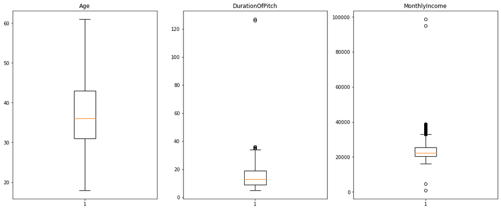

```python
# outlier detection using boxplot
plt.figure(figsize=(20,30))

for i, variable in enumerate(['Age','DurationOfPitch','MonthlyIncome']):
                     plt.subplot(5,4,i+1)
                     plt.boxplot(df[variable],whis=1.5)
                     plt.tight_layout()
                     plt.title(variable)

plt.show()
```

```python
# Checking the extreme values in  DurationOfPitch
df.sort_values(by=["DurationOfPitch"],ascending = False).head(5)
```

|  | ProdTaken | Age | TypeofContact | CityTier | DurationOfPitch | Occupation | Gender | NumberOfPersonVisited | NumberOfFollowups | ProductPitched | PreferredPropertyStar | MaritalStatus | NumberOfTrips | Passport | PitchSatisfactionScore | OwnCar | NumberOfChildrenVisited | Designation | MonthlyIncome |
| --- | --- | --- | --- | --- | --- | --- | --- | --- | --- | --- | --- | --- | --- | --- | --- | --- | --- | --- | --- |
| 3878 | 0 | 53.0 | Company Invited | 3 | 127.0 | Salaried | Male | 3 | 4.0 | Basic | 3.0 | Married | 4.0 | 0 | 1 | 1 | 2.0 | Executive | 22160.0 |
| 1434 | 0 | 32.0 | Company Invited | 3 | 126.0 | Salaried | Male | 2 | 3.0 | Basic | 3.0 | Married | 3.0 | 0 | 1 | 1 | 1.0 | Executive | 18482.0 |
| 3718 | 0 | 32.0 | Self Enquiry | 3 | 36.0 | Small Business | Female | 4 | 5.0 | Deluxe | 3.0 | Married | 3.0 | 0 | 3 | 1 | 1.0 | Manager | 24146.0 |
| 3768 | 0 | 30.0 | Self Enquiry | 1 | 36.0 | Salaried | Male | 4 | 6.0 | Deluxe | 3.0 | Married | 2.0 | 0 | 5 | 1 | 3.0 | Manager | 25062.0 |
| 4738 | 0 | 43.0 | Self Enquiry | 1 | 36.0 | Small Business | Male | 3 | 6.0 | Deluxe | 3.0 | Unmarried | 6.0 | 0 | 3 | 1 | 2.0 | Manager | 22950.0 |

This shows that there are extreme values such as 127 and 126 which can be possible but there are quite extreme

```python
#checking for extreme values in  MonthlyIncome
df.sort_values(by=["MonthlyIncome"],ascending = False).head(5)
```

|  | ProdTaken | Age | TypeofContact | CityTier | DurationOfPitch | Occupation | Gender | NumberOfPersonVisited | NumberOfFollowups | ProductPitched | PreferredPropertyStar | MaritalStatus | NumberOfTrips | Passport | PitchSatisfactionScore | OwnCar | NumberOfChildrenVisited | Designation | MonthlyIncome |
| --- | --- | --- | --- | --- | --- | --- | --- | --- | --- | --- | --- | --- | --- | --- | --- | --- | --- | --- | --- |
| 2482 | 0 | 37.0 | Self Enquiry | 1 | 12.0 | Salaried | Female | 3 | 5.0 | Basic | 5.0 | Divorced | 2.0 | 1 | 2 | 1 | 1.0 | Executive | 98678.0 |
| 38 | 0 | 36.0 | Self Enquiry | 1 | 11.0 | Salaried | Female | 2 | 4.0 | Basic | 3.0 | Divorced | 1.0 | 1 | 2 | 1 | 0.0 | Executive | 95000.0 |
| 2634 | 0 | 53.0 | Self Enquiry | 1 | 7.0 | Salaried | Male | 4 | 5.0 | King | 3.0 | Divorced | 2.0 | 0 | 2 | 1 | 2.0 | VP | 38677.0 |
| 4104 | 0 | 53.0 | Self Enquiry | 1 | 7.0 | Salaried | Male | 4 | 5.0 | King | 3.0 | Married | 2.0 | 0 | 1 | 1 | 3.0 | VP | 38677.0 |
| 3190 | 0 | 42.0 | Company Invited | 1 | 14.0 | Salaried | Female | 3 | 6.0 | King | 3.0 | Married | 3.0 | 0 | 4 | 1 | 1.0 | VP | 38651.0 |

It is unclear to see if there are actual outliers in this variable, so I would carry out other outlier detections before treating them

```python
# Checking for  extreme values  NumberOfTrips
df.sort_values(by=["NumberOfTrips"],ascending = False).head(5)
```

|  | ProdTaken | Age | TypeofContact | CityTier | DurationOfPitch | Occupation | Gender | NumberOfPersonVisited | NumberOfFollowups | ProductPitched | PreferredPropertyStar | MaritalStatus | NumberOfTrips | Passport | PitchSatisfactionScore | OwnCar | NumberOfChildrenVisited | Designation | MonthlyIncome |
| --- | --- | --- | --- | --- | --- | --- | --- | --- | --- | --- | --- | --- | --- | --- | --- | --- | --- | --- | --- |
| 3260 | 0 | 40.0 | Company Invited | 1 | 16.0 | Salaried | Male | 4 | 4.0 | Deluxe | 4.0 | Unmarried | 22.0 | 0 | 2 | 1 | 1.0 | Manager | 25460.0 |
| 816 | 0 | 39.0 | Company Invited | 1 | 15.0 | Salaried | Male | 3 | 3.0 | Deluxe | 4.0 | Unmarried | 21.0 | 0 | 2 | 1 | 0.0 | Manager | 21782.0 |
| 2829 | 1 | 31.0 | Company Invited | 1 | 11.0 | Large Business | Male | 3 | 4.0 | Basic | 3.0 | Single | 20.0 | 1 | 4 | 1 | 2.0 | Executive | 20963.0 |
| 385 | 1 | 30.0 | Company Invited | 1 | 10.0 | Large Business | Male | 2 | 3.0 | Basic | 3.0 | Single | 19.0 | 1 | 4 | 1 | 1.0 | Executive | 17285.0 |
| 4596 | 0 | 33.0 | Company Invited | 1 | 7.0 | Salaried | Female | 4 | 5.0 | Basic | 4.0 | Married | 8.0 | 0 | 3 | 0 | 3.0 | Executive | 21010.0 |

There are some outliers however they are not there without reason so I would decide not to treat them because it might aid me while generating insights during model building.

```python
df.info()
```

```
<class 'pandas.core.frame.DataFrame'>
RangeIndex: 4888 entries, 0 to 4887
Data columns (total 19 columns):
 #   Column                   Non-Null Count  Dtype
---  ------                   --------------  -----
 0   ProdTaken                4888 non-null   int64
 1   Age                      4888 non-null   float64
 2   TypeofContact            4888 non-null   category
 3   CityTier                 4888 non-null   int64
 4   DurationOfPitch          4888 non-null   float64
 5   Occupation               4888 non-null   object
 6   Gender                   4888 non-null   object
 7   NumberOfPersonVisited    4888 non-null   int64
 8   NumberOfFollowups        4888 non-null   category
 9   ProductPitched           4888 non-null   object
 10  PreferredPropertyStar    4888 non-null   category
 11  MaritalStatus            4888 non-null   object
 12  NumberOfTrips            4888 non-null   category
 13  Passport                 4888 non-null   int64
 14  PitchSatisfactionScore   4888 non-null   int64
 15  OwnCar                   4888 non-null   int64
 16  NumberOfChildrenVisited  4888 non-null   float64
 17  Designation              4888 non-null   object
 18  MonthlyIncome            4888 non-null   float64
dtypes: category(4), float64(4), int64(6), object(5)
memory usage: 592.8+ KB
```

```python
df['DurationOfPitch'].describe()
```

```
count    4888.000000
mean       15.362930
std         8.316166
min         5.000000
25%         9.000000
50%        13.000000
75%        19.000000
max       127.000000
Name: DurationOfPitch, dtype: float64
```

```python
df['NumberOfTrips'].describe()
```

```
count     4888.0
unique      12.0
top          2.0
freq      1604.0
Name: NumberOfTrips, dtype: float64
```

# Model Building

1. Data preparation
2. Splitting the dataset into test and train
3. Build a model from the train data
4. Hypertuning the model
5. Run the data on the test dataset

## Spliting the dataset

From the above EDA it is clear that there are imbalanced distribution among the class variables. Hence, we would use stratified sampling to make sure that that the class frequencies are relatively sustained in both the training and test dataset

Since we are going to use startify sampling the parameter that would be used for this is callled train_test_split function.

We are also going to split the dataset into 70:30 and we are going to drop some variables

```python
# Separating the features and the target column
X = df.drop(['ProdTaken','PitchSatisfactionScore','ProductPitched','NumberOfFollowups','DurationOfPitch'],axis=1)
X = pd.get_dummies(X,drop_first=True)
y = df['ProdTaken']
```

```python
#now we are going to split the data into train and test sets in 70:30 ratio
X_train, X_test, y_train, y_test = train_test_split(X, y, test_size=0.30, random_state=1,stratify=y)
```

```python
X_train.shape, X_test.shape
```

```
((3421, 32), (1467, 32))
```

```python
y.value_counts(1)
```

```
0    0.811784
1    0.188216
Name: ProdTaken, dtype: float64
```

```python
y_test.value_counts(1)
```

```
0    0.811861
1    0.188139
Name: ProdTaken, dtype: float64
```

# Model Evaluation Criterion

In order to prevent myself from making the wrong prediction such as :

- A customer can purchase the travel package when the customer does not actually purchase the travel package
- Also predicting that a customer will not purchase the travel package whereas the customer actually purchases the travel package

So it is important to understand the dataset further if we want to achieve better insights. Since the dataset is focused on a travel company that wants to cut the cost of marketing. Hence, it will be better to predict a customer that will purchase the travel package when the customer does not actually purchase the travel package in order to reduce the cost of marketing and places more focus on customers who would buy the travel package

So the direction for us to take is to centre our focus on Precision to be maximized, greater the Precision higher the chances of minimizing false positives. Hence, the focus should be on increasing Precision or minimizing the false positives or in other words identifying the true positives,so that the company can focus on customers who will actually purchase the travel package and hence reduce marketing cost for the company

# Decision Tree

so what we are going to do here is defining the function to provide metric scores on the test and training set and a function to show confusipn matrix

```python
#this is the function to calculate precision score
def get_precision_score(model,flag=True):
    '''
    model : classifier to predict values of X

    '''
    b = []  #this would be defining an empty list to store train and test results
    pred_train = model.predict(X_train)
    pred_test = model.predict(X_test)
    train_precision = metrics.precision_score(y_train,pred_train)
    test_precision = metrics.precision_score(y_test,pred_test)
    b.append(train_precision) # adding train precision to list
    b.append(test_precision) # adding test precision to list
    if flag == True: # if the flag is set to True then only the following print statements will be dispayed
        print("Precision on training set : ",metrics.precision_score(y_train,pred_train))
        print("Precision on test set : ",metrics.precision_score(y_test,pred_test))

    return b # returning the list with train and test scores
```

```python
#this is the function to calculate recall score
def get_recall_score(model,flag=True):
    '''
    model : classifier to predict values of X

    '''
    a = [] #this would be defining an empty list to store train and test results
    pred_train = model.predict(X_train)
    pred_test = model.predict(X_test)
    train_recall = metrics.recall_score(y_train,pred_train)
    test_recall = metrics.recall_score(y_test,pred_test)
    a.append(train_recall) # adding train recall to list
    a.append(test_recall) # adding test recall to list
    if flag == True: #if the flag is set to True then only the following print statements will be dispayed
        print("Recall on training set : ",metrics.recall_score(y_train,pred_train))
        print("Recall on test set : ",metrics.recall_score(y_test,pred_test))

    return a # returning the list with train and test scores
```

```python
#this is the function to calculate accuracy score
def get_accuracy_score(model,flag=True):
    '''
    model : classifier to predict values of X

    '''
    c = [] #this would be defining an empty list to store train and test results
    train_acc = model.score(X_train,y_train)
    test_acc = model.score(X_test,y_test)
    c.append(train_acc) # adding train accuracy to list
    c.append(test_acc) # adding test accuracy to list
    if flag == True: # if the flag is set to True then only the following print statements will be dispayed
        print("Accuracy on training set : ",model.score(X_train,y_train))
        print("Accuracy on test set : ",model.score(X_test,y_test))

    return c # returning the list with train and test scores
```

```python
def make_confusion_matrix(model,y_actual,labels=[1, 0]):
    '''
    model : classifier to predict values of X
    y_actual : ground truth

    '''
    y_predict = model.predict(X_test)
    cm=metrics.confusion_matrix( y_actual, y_predict, labels=[0, 1])
    df_cm = pd.DataFrame(cm, index = [i for i in ["Actual - No","Actual - Yes"]],
                  columns = [i for i in ['Predicted - No','Predicted - Yes']])
    group_counts = ["{0:0.0f}".format(value) for value in
                cm.flatten()]
    group_percentages = ["{0:.2%}".format(value) for value in
                         cm.flatten()/np.sum(cm)]
    labels = [f"{v1}\n{v2}" for v1, v2 in
              zip(group_counts,group_percentages)]
    labels = np.asarray(labels).reshape(2,2)
    plt.figure(figsize = (10,7))
    sns.heatmap(df_cm, annot=labels,fmt='')
    plt.ylabel('True label')
    plt.xlabel('Predicted label')
```

Now we are going to build the model with use of

- DecisionTreeClassifier function with the default set as 'dini' criteria to split and the decision tree will give more weightage to class 1.
- Also class_weight is a hyperparameter for the decision tree classifier.

```python
dtree = DecisionTreeClassifier(criterion='gini',class_weight={0:0.19,1:0.81},random_state=1)
```

```python
dtree.fit(X_train, y_train)
```

```
DecisionTreeClassifier(class_weight={0: 0.19, 1: 0.81}, random_state=1)
```

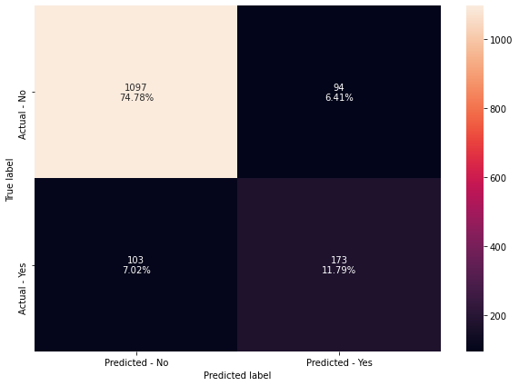

```python
make_confusion_matrix(dtree,y_test)
```

```python
dtree_acc = get_accuracy_score(dtree)
dtree_precision = get_precision_score(dtree)
dtree_recall = get_recall_score(dtree)
```

```
Accuracy on training set :  1.0
Accuracy on test set :  0.8657123381049762
Precision on training set :  1.0
Precision on test set :  0.6479400749063671
Recall on training set :  1.0
Recall on test set :  0.6268115942028986
```

```python
from sklearn.metrics import classification_report, confusion_matrix, accuracy_score
```

### Observation

- It is clear that the decision tree is overfitting the data and also the precision is also not that good.

# Bagging Classifier

```python
bagging = BaggingClassifier(random_state=1)
bagging.fit(X_train,y_train)
```

```
BaggingClassifier(random_state=1)
```

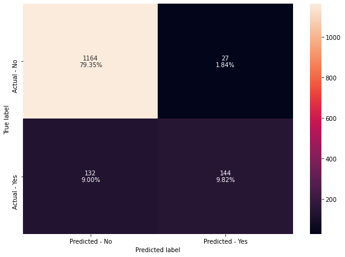

```python
make_confusion_matrix(bagging,y_test)
```

```python
bagging_acc = get_accuracy_score(bagging)
bagging_precision = get_precision_score(bagging)
bagging_recall = get_recall_score(bagging)
```

```
Accuracy on training set :  0.9923998830751243
Accuracy on test set :  0.8916155419222904
Precision on training set :  0.9967845659163987
Precision on test set :  0.8421052631578947
Recall on training set :  0.9627329192546584
Recall on test set :  0.5217391304347826
```

## Bagging Classifier with the weighted Decision Tree

```python
bagging_wt = BaggingClassifier(base_estimator=DecisionTreeClassifier(criterion='gini',class_weight={0:0.19,1:0.81},random_state=1),random_state=1)
bagging_wt.fit(X_train,y_train)
```

```
BaggingClassifier(base_estimator=DecisionTreeClassifier(class_weight={0: 0.19,
                                                                      1: 0.81},
                                                        random_state=1),
                  random_state=1)
```

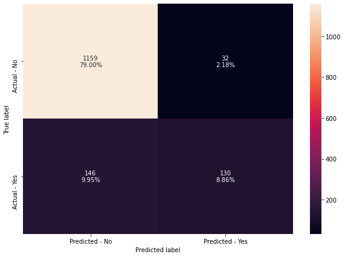

```python
make_confusion_matrix(bagging_wt,y_test)
```

```python
wt_bagging_acc = get_accuracy_score(bagging_wt)
wt_bagging_precision = get_precision_score(bagging_wt)
wt_bagging_recall = get_recall_score(bagging_wt)
```

```
Accuracy on training set :  0.9909383221280328
Accuracy on test set :  0.8786639400136332
Precision on training set :  0.9967585089141004
Precision on test set :  0.8024691358024691
Recall on training set :  0.9549689440993789
Recall on test set :  0.47101449275362317
```

# Random Forest

```python
rf = RandomForestClassifier(random_state=1)
rf.fit(X_train,y_train)
```

```
RandomForestClassifier(random_state=1)
```

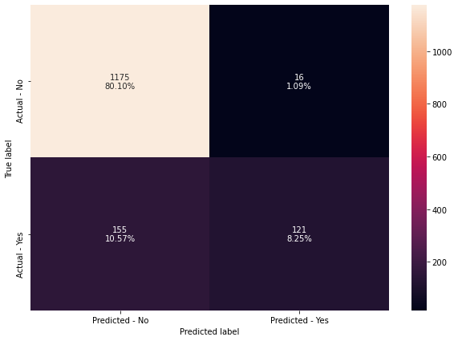

```python
make_confusion_matrix(rf,y_test)
```

```python
rf_acc = get_accuracy_score(rf)
rf_precision = get_precision_score(rf)
rf_recall = get_recall_score(rf)
```

```
Accuracy on training set :  1.0
Accuracy on test set :  0.8834355828220859
Precision on training set :  1.0
Precision on test set :  0.8832116788321168
Recall on training set :  1.0
Recall on test set :  0.4384057971014493
```

- Percision is looking good however Recall seems to have dropped

## Random Forest with Class Weights

```python
rf_wt = RandomForestClassifier(class_weight={0:0.19,1:0.81}, random_state=1)
rf_wt.fit(X_train,y_train)
```

```
RandomForestClassifier(class_weight={0: 0.19, 1: 0.81}, random_state=1)
```

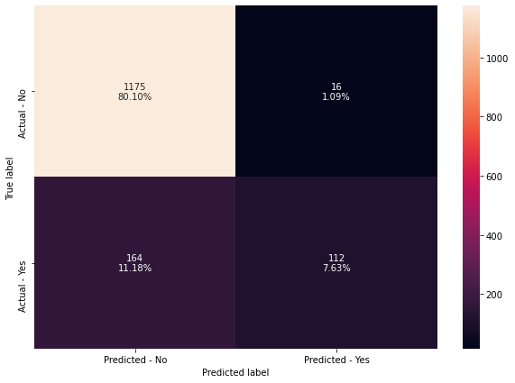

```python
make_confusion_matrix(rf_wt,y_test)
```

```python
wt_rf_acc = get_accuracy_score(rf_wt)
wt_rf_precision = get_precision_score(rf_wt)
wt_rf_recall = get_recall_score(rf_wt)
```

```
Accuracy on training set :  1.0
Accuracy on test set :  0.8773006134969326
Precision on training set :  1.0
Precision on test set :  0.875
Recall on training set :  1.0
Recall on test set :  0.4057971014492754
```

## Model Performance Evaluation and Improvement-Bagging

- Customer purchased package and model predicted customer will purchase travel package : True Positive (observed=1,predicted=1)
- Customer did not purchase package and model predicted customer will purchase travel package : False Postive (observed=0,predicted=1)
- Customer didnot purchase package and model predicted customer will not purchase travel package : True Negative (observed=0,predicted=0)
- Customer purchased package and model predicted customer will not purchase travel package : False Negative (observed=1,predicted=0)

##### In order to see if we can improvel our model I would suggest we do a tuning of the models by using hyperparameters which will be optimised by cross-validation grid search.

### Hypertuning Decision Tree

```python
#this is to choose the type of classifier.
dtree_estimator = DecisionTreeClassifier(class_weight={0:0.19,1:0.81},random_state=1)

#for the grid of parameters to choose from
parameters = {'max_depth': np.arange(2,30),
              'min_samples_leaf': [1, 2, 5, 10, 15],
              'max_leaf_nodes' : [2, 3, 5, 10,15],
              'min_impurity_decrease': [0.0001,0.001,0.01,0.1]
             }

#the type of scoring used to compare parameter combinations
scorer = metrics.make_scorer(metrics.precision_score)

#to help run the grid search
grid_obj = GridSearchCV(dtree_estimator, parameters, scoring=scorer)
grid_obj = grid_obj.fit(X_train, y_train)

#to set the clf to the best combination of parameters
dtree_estimator = grid_obj.best_estimator_

#help find the fit the best algorithm to the data.
dtree_estimator.fit(X_train, y_train)
```

```
DecisionTreeClassifier(class_weight={0: 0.19, 1: 0.81}, max_depth=3,
                       max_leaf_nodes=10, min_impurity_decrease=0.0001,
                       random_state=1)
```

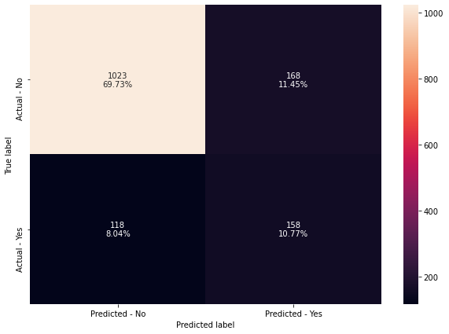

```python
make_confusion_matrix(dtree_estimator,y_test)
```

```python
tuned_dtree_acc = get_accuracy_score(dtree_estimator)
tuned_dtree_precision = get_precision_score(dtree_estimator)
tuned_dtree_recall = get_recall_score(dtree_estimator)
```

```
Accuracy on training set :  0.7836889798304589
Accuracy on test set :  0.8050443081117927
Precision on training set :  0.44244604316546765
Precision on test set :  0.48466257668711654
Recall on training set :  0.5729813664596274
Recall on test set :  0.572463768115942
```

### Hypertunning Bagging Classifier

```python
#getting the grid search for bagging classifier
cl1 = DecisionTreeClassifier(class_weight={0:0.19,1:0.81},random_state=1)
param_grid = {'base_estimator':[cl1],
              'n_estimators':[5,7,15,51,101],
              'max_features': [0.7,0.8,0.9,1]
             }

grid = GridSearchCV(BaggingClassifier(random_state=1,bootstrap=True), param_grid=param_grid, scoring = 'precision', cv = 5)
grid.fit(X_train, y_train)
```

```
GridSearchCV(cv=5, estimator=BaggingClassifier(random_state=1),
             param_grid={'base_estimator': [DecisionTreeClassifier(class_weight={0: 0.19,
                                                                                 1: 0.81},
                                                                   random_state=1)],
                         'max_features': [0.7, 0.8, 0.9, 1],
                         'n_estimators': [5, 7, 15, 51, 101]},
             scoring='precision')
```

```python
##trying to see which one is the best estimator
bagging_estimator  = grid.best_estimator_
bagging_estimator.fit(X_train,y_train)
```

```
BaggingClassifier(base_estimator=DecisionTreeClassifier(class_weight={0: 0.19,
                                                                      1: 0.81},
                                                        random_state=1),
                  max_features=0.7, n_estimators=101, random_state=1)
```

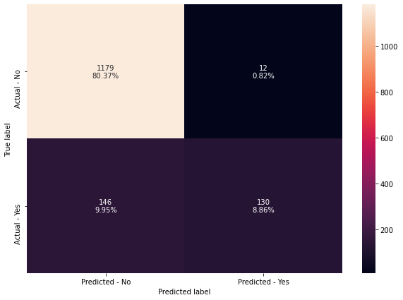

```python
make_confusion_matrix(bagging_estimator,y_test)
```

```python
tuned_bagging_acc= get_accuracy_score(bagging_estimator)
tuned_bagging_precision = get_precision_score(bagging_estimator)
tuned_bagging_recall = get_recall_score(bagging_estimator)
```

```
Accuracy on training set :  1.0
Accuracy on test set :  0.8922972051806408
Precision on training set :  1.0
Precision on test set :  0.9154929577464789
Recall on training set :  1.0
Recall on test set :  0.47101449275362317
```

### Hypertuning Random Forest

```python
#to help choose the type of classifier.
rf_estimator = RandomForestClassifier(random_state=1)

#check the grid of parameters to choose from
parameters = {
        "n_estimators": [110,251,501],
        "min_samples_leaf": np.arange(1, 6,1),
        "max_features": [0.7,0.9,'log2','auto'],
        "max_samples": [0.7,0.9,None],
}


# Run the grid search
grid_obj = GridSearchCV(rf_estimator, parameters, scoring='precision',cv=5)
grid_obj = grid_obj.fit(X_train, y_train)

#to the best combination of parameters
rf_estimator = grid_obj.best_estimator_

# Fit the best algorithm to the data.
rf_estimator.fit(X_train, y_train)
```

```
RandomForestClassifier(max_features='log2', max_samples=0.9, n_estimators=501,
                       random_state=1)
```

```python
tuned_rf_acc = get_accuracy_score(rf_estimator)
tuned_rf_precision = get_precision_score(rf_estimator)
tuned_rf_recall = get_recall_score(rf_estimator)
```

```
Accuracy on training set :  1.0
Accuracy on test set :  0.885480572597137
Precision on training set :  1.0
Precision on test set :  0.875
Recall on training set :  1.0
Recall on test set :  0.45652173913043476
```

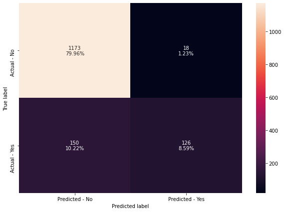

```python
make_confusion_matrix(rf_estimator,y_test)
```

Even still after hypertunning the Random Forest the model still displays that there is still overfitting in the data

## Comparing the models

##### We are going to define the list of models for Decision Tree,Bagging Classifier and Random Forest with and without Tuning comaprison and see which model are best fit for the model

```python
#this will be for defining list of models
models = [dtree,bagging,bagging_wt,rf,rf_wt,dtree_estimator,bagging_estimator,rf_estimator]
#while this is for defining empty lists to add train and test results
acc_train = []
acc_test = []
recall_train = []
recall_test = []
precision_train = []
precision_test = []

#now we would be looping through all the models to get the accuracy,recall and precision scores
for model in models:
    #for accuracy score
    j = get_accuracy_score(model,False)
    acc_train.append(j[0])
    acc_test.append(j[1])
    #for recall score
    k = get_recall_score(model,False)
    recall_train.append(k[0])
    recall_test.append(k[1])
    #for precision score
    l = get_precision_score(model,False)
    precision_train.append(l[0])
    precision_test.append(l[1])
```

```python
#to create the table to show the list of the various forms of model building for easier interpretation
comparison_frame = pd.DataFrame({'Model':['Decision Tree','Bagging Classifier','Bagging Classifier with weighted decision tree',
                                          'Random Forest','RandomForest With Class weigths','Tuned Decision Tree','Tuned Bagging Classifier','Tuned Random Forest'],
                                          'Train_Accuracy': acc_train,
                                          'Test_Accuracy': acc_test,
                                          'Train_Precision': precision_train,
                                          'Test_Precision': precision_test,
                                          'Train_Recall': recall_train,
                                          'Test_Recall': recall_test
                                          })

comparison_frame
```

|  | Model | Train_Accuracy | Test_Accuracy | Train_Precision | Test_Precision | Train_Recall | Test_Recall |
| --- | --- | --- | --- | --- | --- | --- | --- |
| 0 | Decision Tree | 1.000000 | 0.865712 | 1.000000 | 0.647940 | 1.000000 | 0.626812 |
| 1 | Bagging Classifier | 0.992400 | 0.891616 | 0.996785 | 0.842105 | 0.962733 | 0.521739 |
| 2 | Bagging Classifier with weighted decision tree | 0.990938 | 0.878664 | 0.996759 | 0.802469 | 0.954969 | 0.471014 |
| 3 | Random Forest | 1.000000 | 0.883436 | 1.000000 | 0.883212 | 1.000000 | 0.438406 |
| 4 | RandomForest With Class weigths | 1.000000 | 0.877301 | 1.000000 | 0.875000 | 1.000000 | 0.405797 |
| 5 | Tuned Decision Tree | 0.783689 | 0.805044 | 0.442446 | 0.484663 | 0.572981 | 0.572464 |
| 6 | Tuned Bagging Classifier | 1.000000 | 0.892297 | 1.000000 | 0.915493 | 1.000000 | 0.471014 |
| 7 | Tuned Random Forest | 1.000000 | 0.885481 | 1.000000 | 0.875000 | 1.000000 | 0.456522 |

So from the comparison frame above we can deduce that:

- Hypertuned Bagging classifier has the highest precision
- Hypertuned Bagging classifier also has a good accuracy
- Also RandomForest With Class weigths is good to

### Now we are going to check the important features of the RandomForest With Class weigths

#### This can also be called the Gini importance

```python
print (pd.DataFrame(rf_wt.feature_importances_, columns = ["Imp"], index = X_train.columns).sort_values(by = 'Imp', ascending = False))
#this is the code to check the gini importance
```

```
                                 Imp
MonthlyIncome               0.161038
Age                         0.149760
Passport                    0.081975
CityTier                    0.049464
NumberOfChildrenVisited     0.045178
NumberOfPersonVisited       0.041003
Designation_Executive       0.039061
Gender_Male                 0.034689
TypeofContact_Self Enquiry  0.032072
OwnCar                      0.030795
MaritalStatus_Single        0.030266
PreferredPropertyStar_5.0   0.028606
PreferredPropertyStar_4.0   0.026183
MaritalStatus_Married       0.025494
Designation_Manager         0.024475
NumberOfTrips_2.0           0.024104
Occupation_Small Business   0.022420
Occupation_Salaried         0.021895
NumberOfTrips_3.0           0.020045
MaritalStatus_Unmarried     0.019712
Occupation_Large Business   0.015756
Designation_Senior Manager  0.015087
NumberOfTrips_5.0           0.013077
NumberOfTrips_4.0           0.012539
NumberOfTrips_6.0           0.012282
NumberOfTrips_7.0           0.011403
NumberOfTrips_8.0           0.005869
Designation_VP              0.005659
NumberOfTrips_19.0          0.000058
NumberOfTrips_22.0          0.000029
NumberOfTrips_21.0          0.000003
NumberOfTrips_20.0          0.000000
```

```python
feature_names = X_train.columns
```

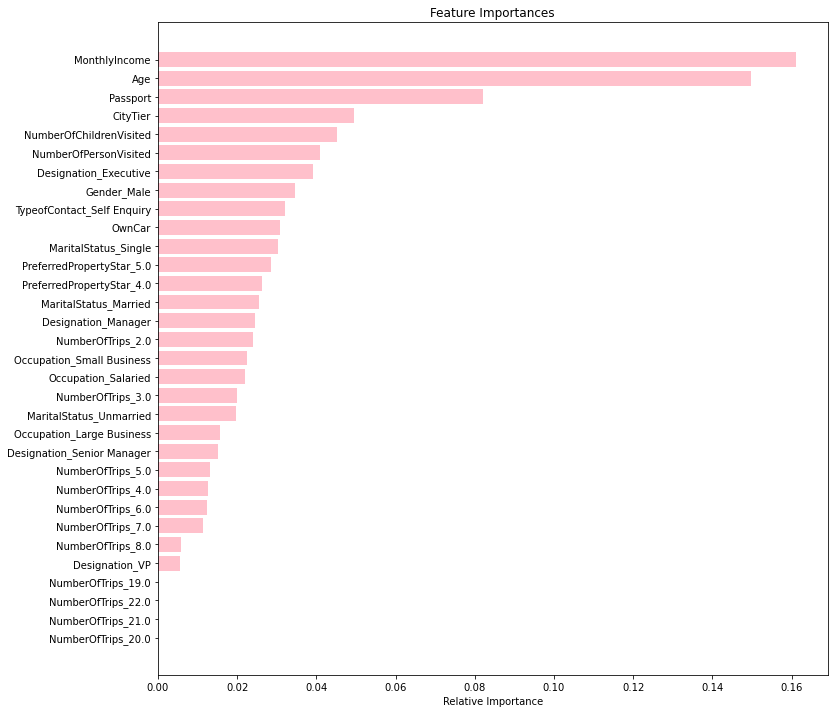

```python
#this is to create the a graphical form of the above representation of the Gini importance
importances = rf_wt.feature_importances_
indices = np.argsort(importances)

plt.figure(figsize=(12,12))
plt.title('Feature Importances')
plt.barh(range(len(indices)), importances[indices], color='pink', align='center')
plt.yticks(range(len(indices)), [feature_names[i] for i in indices])
plt.xlabel('Relative Importance')
plt.show()
```

#### Observation

- The top features which were selected by RandomForest With Class weigths are Monthly Income, Age, Passport, CityTier and NumberOfChildrenVisited